# Tema 0: Introducción a R y Positron (Posit)

Análisis de Datos Multivariantes aplicado al Marketing - Curso 2026/27  
Universidad de Alicante

Pedro Albarrán

Dpto. de Fundamentos del Análisis Económico. Universidad de Alicante

# Conceptos básicos

## Introducción

- **R** es el lenguaje: ejecuta instrucciones directamente en una consola (es *interpretado*)
- **Positron** es el entorno de trabajo (IDE): derivado de VS Code, uno de los editores más usados
  - Misma interfaz y manejo, con añadidos específicos para el análisis de datos en R y Python
  - Se puede usar VS Code “puro” de forma muy similar
- Instalación: página Puesta a punto de la web (si no lo tenéis, LO ANTES POSIBLE)
- Este tema: de los primeros comandos hasta empezar a trabajar con datos; el material de cada sesión, siempre en Contenidos

## Positron

[figure not shown]

- **Editor** (scripts) y **Consola** (ejecutar comandos y ver resultados); a la derecha, **Variables** (objetos en memoria) y **Gráficos**; a la izquierda, el **Explorador** de archivos

## Empezando: elegir el intérprete de R

- Al abrir Positron aparece la zona de **consola** (panel inferior), PERO hay que **elegir el intérprete**: pulsad en el selector de la esquina superior derecha y elegid **R** (versión 4.6.x)

[figure not shown]

- OJO: si aparece **Python**, NO es un error vuestro, pero NO es lo que usamos: cambiad a R en ese mismo selector (*New Console Session…*)

## La Consola

- Escribimos *comandos* en la **consola** y se ejecutan pulsando `Enter`:
  - La tecla de tabulador

[figure not shown]

    ofrece opciones de autocompletado
  - Ejecutar algo que no es un **comando de R** devuelve un error

```r
2 + 2
3 * (1 - 4)^2
sqrt(log(5 / 2))
pi
hola
```

## Archivos de guion (“scripts”)

- Es preferible incluir varios comandos en un archivo de texto para ejecutarlos
- Se puede replicar el proceso de cálculos paso a paso (no como Excel)
- Creamos un nuevo archivo en el menú *File > New File…* eligiendo *R File*
- Guardamos el archivo en *File > Save* (atajo `Ctrl + S`), eligiendo un directorio y nombre con extensión “.R” (por defecto) o “.r”
- Desde el editor, `Ctrl+Enter` envía a la consola la línea actual o las líneas seleccionadas (en MacOS, la tecla `Command` en lugar de `Ctrl`)
- En un archivo de guion (guardado), Positron marca las líneas con error y muestra el mensaje de error al pasar el puntero

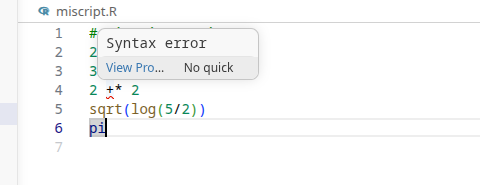

## Trabajar con ficheros de guion

- Cada comando es “una” línea y se ejecutan secuencialmente
- Un comando se puede extender visualmente más de una línea hasta completarse: p.e., hasta cerrar los paréntesis.
  - Escribimos `log(`, en otra línea `9` y ejecutamos: la consola cambia de `>` a `+`
  - No hace “nada” esperando que completemos el comando.
- El carácter `#` marca el inicio de un **comentario**: lo que sigue se “ignora” (no se ejecuta) en R

```r
# Pueden ir al principio de la línea
2 + 2 # o después de una instrucción
```

- Comentar es un buen hábito: ayuda a entender/recordar qué hacemos
- Notad que Positron tiene *resaltado de sintaxis*: distinto color para comentarios, números, funciones, etc.

## Directorio de Trabajo. Proyectos.

- Conviene **organizar los archivos** relacionados con un mismo tema en una estructura de (sub)directorios a partir de un **directorio de trabajo** principal
- En la programación moderna (Positron, VS Code y la mayoría de editores actuales), un **proyecto** ES simplemente una **carpeta**
- Cread una carpeta para el curso (p.e. `AnalisisDatos`) con subcarpetas para datos, código, etc., y abridla con *File > Open Folder*
- Sin carpeta abierta, el **Explorador** (barra izquierda) solo ofrece precisamente eso: *Open Folder*

[figure not shown]

## La primera vez que abrís la carpeta

- Al abrir una carpeta por primera vez, Positron pregunta si **confiáis** en sus archivos: pulsad **“Yes, I trust the authors”** (es vuestra carpeta: la acabáis de crear)
- Si contestáis que no, Positron queda en **modo restringido**: sin consola de R, sin resaltado, sin casi nada; se arregla pulsando en *Restricted Mode* (abajo a la izquierda) y confiando la carpeta

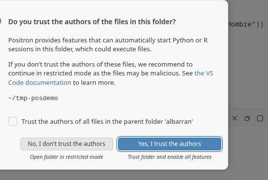

- Con la carpeta abierta, esa carpeta es vuestro **directorio de trabajo**: R busca y guarda los archivos ahí (usad rutas RELATIVAS, como veremos)
- Al abrir Positron se recupera la última carpeta usada; con *File > Open Recent* podéis cambiar entre carpetas (p.e., otra asignatura u otro proyecto)

## Proyectos (cont.)

- Para trabajar con un archivo, usamos la **ruta relativa** al directorio de trabajo:
  - si están en el raíz del directorio: `codigo.R`, `misdatos.Rdata`
  - si están en un subdirectorio, indicamos la ruta separando directorios por `/`: `datos/ventas.Rdata`, `datos/ano2020/ingresos.Rdata`
- Las rutas relativas son otra idea general de la programación: el proyecto funciona igual en cualquier ordenador (la ruta completa `C:/Users/minombre/...` solo existe en el vuestro)

## Proyectos: siempre una carpeta, a veces con ajustes

- Todo el trabajo sucede **dentro de un directorio**. Eso ES el proyecto, y con eso basta: abrir una carpeta ya es decir “este es mi directorio de trabajo, aquí organizo mis datos, mi código y mis resultados”
- Lo demás que oiréis nombrar son **la misma carpeta con un fichero de ajustes añadido**:

|  | qué es | para qué |
| --- | --- | --- |
| carpeta abierta | *File > Open Folder* | lo que usamos en el curso |
| **proyecto de R** | la misma carpeta + un fichero **`.Rproj`** | guarda ajustes de R que queréis conservar para ese proyecto, y al abrirlo fija el directorio de trabajo |
| **proyecto de Quarto** | la misma carpeta + un fichero **`_quarto.yml`** | ajustes comunes a **muchos** documentos de Quarto, para no repetirlos en cada uno |

- Para dos o tres ejercicios sueltos no hace falta ninguna de las dos cosas

## Ficheros que R crea solo

- Trabajando con R aparecerán en vuestra carpeta ficheros que no habéis creado vosotros:
  - **`.RData`**: el **espacio de trabajo** guardado, es decir, los objetos que había en memoria
  - **`.Rhistory`**: el **historial** de órdenes que habéis escrito en la consola
  - **`.Rproj.user`**: una carpeta oculta con ficheros temporales, si usáis un proyecto de R
- Los tres los genera R por su cuenta: son **estado de vuestra sesión**, no vuestro trabajo. No se entregan y no hace falta tocarlos

## El Explorador y la barra lateral

- El **Explorador** (icono de archivos en la barra lateral izquierda) ofrece una forma visual de abrir, crear, copiar, mover o eliminar archivos y carpetas
- El Explorador solo muestra **lo que está DENTRO de la carpeta abierta**: lo de fuera no se ve ni se puede tocar desde aquí
  - Por eso hay que pensar QUÉ pertenece al proyecto (datos, scripts…) y traerlo a la carpeta (arrastrándolo al Explorador, o copiándolo con el explorador del sistema)
- Esa barra lateral tiene mucho más (extensiones, asistente de IA, control de versiones, búsqueda): NO lo necesitáis por ahora; la ayuda y la IA integradas las iremos usando poco a poco
- Evitad caracteres “raros” (acentos, espacios, etc.) en directorios y ficheros
- NOTA. El Explorador de Archivos de Windows y Finder de MacOS no muestran por defecto las extensiones de los archivos.
  - Puede ser confuso para distinguir entre dos archivos con el mismo nombre y diferente extensión: `proyecto.R` y `proyecto.qmd`
  - Consultad cómo mostrarlas: p.e., para [Windows](https://support.microsoft.com/es-es/windows/extensiones-de-nombre-de-archivo-comunes-en-windows-da4a4430-8e76-89c5-59f7-1cdbbc75cb01) y [MacOS](https://support.apple.com/es-es/guide/script-editor/scpedt1025/mac)

## Funciones en R

- Las expresiones que aceptan **argumentos** se denominan funciones.

```r
exp(2)
ceiling(5.2)
```

- Algunos argumentos son obligatorios, otros tienen valores por defecto que se pueden omitir
- Los argumentos se pueden especificar por nombre o por orden.

```r
log(2, base = 2)
log(2, 10)
log(base = 10, x = 2)
```

- ¿Cómo sabemos la manera de usar una función (ej. argumentos necesarios) o comando de R?

## Ayuda en R y Positron

- Positron tiene autocompletado (tecla tabulador) y ayuda flotante para funciones y otros elementos de R

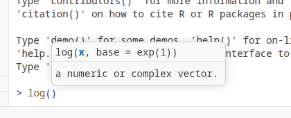

- Positron también tiene un panel de **Ayuda** (Help): `F1` sobre una función, o `?min` / `help(min)` en la consola

## La IA como ayuda (usada con cabeza)

- Positron incluye un **asistente de IA** (icono de chat en la barra lateral), que se conecta a proveedores como Copilot o Claude; también en VS Code, y siempre están las IAs externas (ChatGPT, Gemini…)
- Usos LEGÍTIMOS que os harán mejores: pedir que os **explique** un mensaje de error, recordar la sintaxis de una función, entender un código ajeno
- Uso que os hará PEORES: dejar que **reescriba vuestro código sin entenderlo**: no aprendéis, no detectáis sus errores… y en la evaluación se nota
- La disciplina es la misma que el *pensamiento algorítmico* del primer día:
  1. especificar CON PRECISIÓN el problema (también al preguntar a una IA)
  2. descomponerlo en pasos
  3. COMPROBAR el resultado (¿hace lo que quería? ¿con qué casos falla?)
- Ante un error: leer el mensaje, localizar la línea, formular una hipótesis, probar; la IA ayuda a *entender*, la solución tenéis que entenderla vosotros: copiar-pensar-adaptar

## El operador de asignación

- El operador `<-` almacena un contenido en un *objeto* con un nombre,<sup>1</sup> que incluye letras, números y algunos carácteres especiales (“.”, “_”)

```r
x <- 2 * 3 # asignación, no muestra resultado
x # ejecutamos mostrar la variable
print(x)
(x <- 2) # asignación e impresión a la vez
```

- R es “case-sensitive”: `x` y `X` son dos objetos distintos
- Los objetos asignados pueden usarse posteriormente, p.e., para generar otros a partir de ellos

```r
y <- x + 5 # asignamos y a partir del VALOR de x
(x <- x * 3) # re-asignamos x a partir de ella misma
y # NO cambia (en Excel, sí)
```

[^1]: También se puede asignar con `=`

## El Espacio de Trabajo en R

- El espacio de trabajo es el conjunto de objetos activos en memoria, resultado de todos los comandos ejecutados previamente
- En Positron, el panel **Variables** muestra los objetos y su valor
- Las funciones `ls()` y `rm()` muestran y eliminan respectivamente objetos del espacio de trabajo
- Borramos *todos* los objetos desde el panel Variables o con el comando

```r
rm(list = ls()) # eliminar todos los objetos
rm(y, x) # eliminar solo algunos objetos
```

- Guardar el contenido del entorno de trabajo al cerrar es **innecesario**: ejecutando los comandos guardados en un archivo `.R` recuperamos los objetos

## Mensajes de “Error” y “Warning”

- En programación, cometer **errores** es **normal**
- En muchos errores, R se “quejará” mostrando **mensajes** en rojo
  - *Aviso*: R ofrece un resultado (y continuará al siguiente comando), PERO indica que puede haber algo “no deseado”
  - *Error*: para la ejecución, *sin resultado*, e “informa” de la razón
- Algunos mensajes son claros, pero otros requieren más investigación: pegarlos a una IA y pedir que os los EXPLIQUE es un buen uso; que os reescriba el código sin entenderlo, no
- Peor que un mensaje de error: escribimos (copiamos) un código que funciona pero no hace lo que queremos…
- El ordenador NO se equivoca: hace lo que le pedimos según unas reglas bien definidas por R, que *debemos conocer*
  - Sed cuidadosos, pensad y **entended** cada paso del código